# Portfolio Exercise 2.2, Methods 3, 2021, autumn semester

Alina Kereszt

13.12.2021

# Exercises and objectives

The objectives of the exercises of this assignment are based on: https://doi.org/10.1016/j.concog.2019.03.007

4. Download and organise the data from experiment 1
5. Use log-likelihood ratio tests to evaluate logistic regression models
6. Test linear hypotheses
7. Estimate psychometric functions for the Perceptual Awareness Scale and evaluate them

REMEMBER: In your report, make sure to include code that can reproduce the answers requested in the exercises below (**MAKE A KNITTED VERSION**)  
REMEMBER: This is part 2 of Assignment 2 and will be part of your final portfolio

## EXERCISE 4 - Download and organise the data from experiment 1

Go to https://osf.io/ecxsj/files/ and download the files associated with Experiment 1 (there should be 29).  
The data is associated with Experiment 1 of the article at the following DOI https://doi.org/10.1016/j.concog.2019.03.007

### 1) Put the data from all subjects into a single data frame - note that some of the subjects do not have the *seed* variable. For these subjects, add this variable and make in *NA* for all observations. (The *seed* variable will not be part of the analysis and is not an experimental variable)

```r
df <-
    list.files(pattern = "*.csv") %>%
    map_df(~read_csv(.))
```

```r
# Checking what happens after data gets loaded - it appears that NAs got added automatically where _seed_ was missing
unique(df$seed)
```

```
##  [1] 93764 33409 25494 63023 21722 91366    NA 28587  3849 90992 66788 16969
## [13] 30991 73521  3688 98435 25444  3733 80613 14592  4688 66410 14408 90174
## [25] 24431 41191 18320 61503  4691 23300
```

**i. Factorise the variables that need factorising**

```r
#Encode variables appropriately
#'numeric' is for numbers in general; 'double' is floats, 'integer' is whole numbers
df$trial <- as.numeric(df$trial) # OR INTEGER??? it is ordinal but not exactly continuous...
df$trial.type <- as.factor(df$trial.type)
df$pas <- as.factor(df$pas)
df$target.contrast <- as.numeric(df$target.contrast)
df$cue <- as.factor(df$cue)
df$task <- as.factor(df$task)
df$target.type <- as.factor(df$target.type)
df$rt.subj <- as.numeric(df$rt.subj)
df$rt.obj <- as.numeric(df$rt.obj)
df$obj.resp <- as.factor(df$obj.resp)
df$target.frames <- as.numeric(df$target.frames)

#Anonymize subjects (also facilitates later analysis if the subjects are represented only by numbers)
df$subject <- as.numeric(df$subject)
df$subject <- as.factor(df$subject)
```

**ii. Remove the practice trials from the dataset (see the *trial.type* variable)**

```r
df <- df %>%
  filter(trial.type != "practice")
```

**iii. Create a *correct* variable**

```r
df$correct <- ifelse((df$target.type == "odd" & df$obj.resp == "o") | (df$target.type == "even" & df$obj.resp == "e"), 1, 0)
df$correct <- as.factor(df$correct) #encoded as "factor" because encoding as "logical" changes values to "TRUE" and "FALSE", which is not suitable for running and plotting logistic regression
```

**iv. Describe how the *target.contrast* and *target.frames* variables differ compared to the data from part 1 of this assignment**

```r
unique(df$target.contrast) #check values the variable takes
```

```
## [1] 0.1
```

```r
unique(df$target.frames) #check values the variable takes
```

```
## [1] 3 2 1 5 6 4
```

In part 1 of this assignment, *target.contrast* was varied in the staircasing trials in order to assess what the optimal contrast was between the stimulus and the background for each participant, and this contrast was then maintained in the experimental trials. Here, in part 2, the contrast is the same for all participants.

Meanwhile, in part 1, all participants in all experimental trials saw the stimulus for 3 frames. Here, in part 2, the number of frames the stimulus is presented for varies from trial to trial in all participants.

## EXERCISE 5 - Use log-likelihood ratio tests to evaluate logistic regression models

### 1) Do logistic regression - *correct* as the dependent variable and *target.frames* as the independent variable. (Make sure that you understand what *target.frames* encode). Create two models - a pooled model and a partial-pooling model. The partial-pooling model should include a subject-specific intercept.

```r
model_5.1a <- glm(correct ~ target.frames,
                  family = 'binomial',
                  data = df) #pooled model
model_5.1b <- glmer(correct ~ target.frames + (1 | subject),
                    family = 'binomial',
                    data = df) #partially pooled model
```

**i. the likelihood-function for logistic regression is: $L(p)={\displaystyle\prod_{i=1}^Np^{y_i}(1-p)^{(1-y_i)}}$ (Remember the probability mass function for the Bernoulli Distribution). Create a function that calculates the likelihood.**

```r
# When you run a logistic regression, you're basically working with 3 columns of values: the ground truth (the values _y_ takes on), the log-odds (the output of the model) and the probabilities (the inverse logit of the output).
# The above function works with EVERY SINGLE VALUE contained within the dataset, i.e. yˇi is the ground truth (0 or 1) while p refers to the inverse logit of the fitted values.
# It involves the _BINOMIAL THEOREM_. <-- helps you google!

likelihood <- function(groundtruth, fitted_values) {

  #obtain probability by taking inverse logit of fitted values
  p <- inv.logit(fitted_values)

  #make the variable numeric (and subtract 1 because when you convert numbers from factor to numeric, they begin with 1, not 0)
  y <- as.numeric(groundtruth) - 1

  #run the function for each row
  L_values <- c() #empty vector
  for (row in 1:length(p)){
    L_values[row] <- (p[row] ^ y[row]) * ((1 - p[row]) ^ (1 - y[row]))
  }

  #take the product of all rows in the vector
  product <- prod(L_values)

  #give an output
  return(product)
}
```

**ii. the log-likelihood-function for logistic regression is: $l(p) = {\displaystyle\sum_{i=1}^N}[y_i\ln{p}+(1-y_i)\ln{(1-p)}$. Create a function that calculates the log-likelihood.**

```r
loglikelihood <- function(groundtruth, fitted_values) {

  #here you DO NOT take the inv.logit of the probabilities bc then the function messes up and gives you the wrong answer - log-odds are the natural logarithm of odds
  p <- fitted_values

  #make the variable numeric (and subtract 1 because when you convert numbers from factor to numeric, they begin with 1, not 0)
  y <- as.numeric(groundtruth) - 1

  #run the function for each row
  L_values <- c() #empty vector
  for (row in 1:length(p)){
    L_values[row] <- (y[row] * log(p[row]) + (1 - y[row]) * log(1 - p[row]))
  }

  #take the product of all rows in the vector
  sum <- sum(L_values)

  #give an output
  return(sum)
}
```

**iii. apply both functions to the pooling model you just created. Make sure that the log-likelihood matches what is returned from the *logLik* function for the pooled model. Does the likelihood-function return a value that is surprising? Why is the log-likelihood preferable when working with computers with limited precision?**

```r
likelihood(df$correct, fitted(model_5.1a))
```

```
## [1] 0
```

```r
logLik(model_5.1a)
```

```
## 'log Lik.' -10865.25 (df=2)
```

Probabilities take on values between 0 and 1, meaning that their products end up approximating 0 the more values are taken into consideration (understandably, as the likelihood of obtaining the same 25000 values is extremely low); at a certain point, computers no longer calculate so many decimal places and output “0”. Summing (used in log-likelihood) avoids this issue, even if it means the output is somewhat arbitrary.

**iv. now show that the log-likelihood is a little off when applied to the partial pooling model - (the likelihood function is different for the multilevel function - see section 2.1 of https://www.researchgate.net/profile/Douglas-Bates/publication/2753537_Computational_Methods_for_Multilevel_Modelling/links/00b4953b4108d73427000000/Computational-Methods-for-Multilevel-Modelling.pdf if you are interested)**

```r
loglikelihood(df$correct, fitted(model_5.1b))
```

```
## [1] -10565.53
```

```r
logLik(model_5.1b)
```

```
## 'log Lik.' -10622.03 (df=3)
```

### 2) Use log-likelihood ratio tests to argue for the addition of predictor variables, start from the null model, `glm(correct ~ 1, 'binomial', data)`, then add subject-level intercepts, then add a group-level effect of *target.frames* and finally add subject-level slopes for *target.frames*. Also assess whether or not a correlation between the subject-level slopes and the subject-level intercepts should be included.

*(NB! Exercise 5.2 has been coded in collaboration with the entire study group - Mie Søgaard, Linus Backström, Mikkel Kristensen, Alina Kereszt. The explanations are our own.)*

```r
model_5.2a <- glm(correct ~ 1,
                  family = 'binomial',
                  data = df)
model_5.2b <- lme4::glmer(correct ~ 1 + (1 | subject),
                    family = 'binomial',
                    data = df)
model_5.2c <- lme4::glmer(correct ~ target.frames + (1 | subject),
                    family = 'binomial',
                    data = df) #group-level effect = fixed effect:)
model_5.2d <- lme4::glmer(correct ~ target.frames + (1 + target.frames || subject),
                    family = 'binomial',
                    data = df) # without correlation between random effects; indicated by '||'
model_5.2e <- lme4::glmer(correct ~ target.frames + (1 + target.frames | subject),
                    family = 'binomial',
                    data = df) # with correlation between random effects

anova(model_5.2e, model_5.2d, model_5.2c, model_5.2b, model_5.2a)
```

```
## Data: df
## Models:
## model_5.2a: correct ~ 1
## model_5.2b: correct ~ 1 + (1 | subject)
## model_5.2c: correct ~ target.frames + (1 | subject)
## model_5.2d: correct ~ target.frames + (1 + target.frames || subject)
## model_5.2e: correct ~ target.frames + (1 + target.frames | subject)
##            npar   AIC   BIC logLik deviance    Chisq Df Pr(>Chisq)
## model_5.2a    1 26685 26693 -13342    26683
## model_5.2b    2 26319 26335 -13158    26315  367.980  1  < 2.2e-16 ***
## model_5.2c    3 21250 21274 -10622    21244 5071.035  1  < 2.2e-16 ***
## model_5.2d    4 20929 20961 -10460    20921  323.487  1  < 2.2e-16 ***
## model_5.2e    5 20908 20948 -10449    20898   22.926  1  1.684e-06 ***
## ---
## Signif. codes:  0 '***' 0.001 '**' 0.01 '*' 0.05 '.' 0.1 ' ' 1
```

**i. write a short methods section and a results section where you indicate which model you chose and the statistics relevant for that choice. Include a plot of the estimated group-level function with `xlim=c(0, 8)` that includes the estimated subject-specific functions.**

```r
summary(model_5.2e)$coefficients
```

```
##                 Estimate Std. Error   z value     Pr(>|z|)
## (Intercept)   -1.0900901 0.05876142 -18.55112 7.987049e-77
## target.frames  0.8331614 0.04431965  18.79892 7.707409e-79
```

```r
inv.logit(0.83316)
```

```
## [1] 0.6970227
```

(REPORT PART 1)

We chose model_5.2e in order to best describe the probability of obtaining a correct answer in the task when taking into account the number of target frames presented, as well as unique intercepts by subject and unique slopes by target frames presented (correlation between random effects included):

*correct ~ target.frames + (1 + target.frames | subject)*

The chosen model performs better than the other models in terms of AIC scores. When conducting a log-likelihood ratio test, we found the added complexity to significantly improve log-likelihood scores (χ² (1) = 22.926, p < .001).

**ii. also include in the results section whether the fit didn’t look good for any of the subjects. If so, identify those subjects in the report, and judge (no statistical test) whether their performance (accuracy) differed from that of the other subjects. Was their performance better than chance? (Use a statistical test this time)**

```r
#isolate unruly subject
sub24 <- df %>%
  filter(subject == 24)

#binomial test
table(sub24$correct) #see how many correct and incorrect answers
```

```
##
##   0   1
## 378 496
```

```r
vector <- c(496, 378) #establish vector of length 2 with number of correct and incorrect answers, respectively
binom.test(vector, p = 0.5)
```

```
##
##  Exact binomial test
##
## data:  vector
## number of successes = 496, number of trials = 874, p-value = 7.397e-05
## alternative hypothesis: true probability of success is not equal to 0.5
## 95 percent confidence interval:
##  0.5339074 0.6006475
## sample estimates:
## probability of success
##              0.5675057
```

(REPORT PART 2)

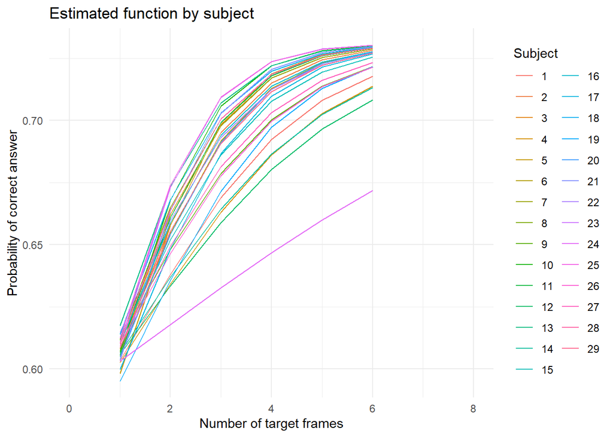

However, as seen in the above plot, the estimated function for subject 24 appears to differ from the other subjects, showing an apparently more linear relationship between accuracy and the number of target frames. They appear to demonstrate lower accuracy compared to the other subjects. When conducting a binomial test on the data for this subject, we found that their performance, albeit poor, to be significantly better than chance, b(874), p < .001.

### 3) Now add *pas* to the group-level effects - if a log-likelihood ratio test justifies this, also add the interaction between *pas* and *target.frames* and check whether a log-likelihood ratio test justifies this

```r
# Establish models
model_5.2f <- glmer(correct ~ target.frames + pas + (target.frames | subject),
                    family = 'binomial',
                    data = df)
model_5.2g <- glmer(correct ~ target.frames * pas + (target.frames | subject),
                    family = 'binomial',
                    data = df,
                    control = glmerControl(optimizer = "bobyqa")) #model wasn't converging so it had to be optimized

# Log-likelihood ratio test
anova(model_5.2g, model_5.2f, model_5.2e)
```

```
## Data: df
## Models:
## model_5.2e: correct ~ target.frames + (1 + target.frames | subject)
## model_5.2f: correct ~ target.frames + pas + (target.frames | subject)
## model_5.2g: correct ~ target.frames * pas + (target.frames | subject)
##            npar   AIC   BIC   logLik deviance   Chisq Df Pr(>Chisq)
## model_5.2e    5 20908 20948 -10448.8    20898
## model_5.2f    8 19880 19945  -9931.8    19864 1033.99  3  < 2.2e-16 ***
## model_5.2g   11 19506 19596  -9742.0    19484  379.58  3  < 2.2e-16 ***
## ---
## Signif. codes:  0 '***' 0.001 '**' 0.01 '*' 0.05 '.' 0.1 ' ' 1
```

The most complex model performs better than the other models in terms of AIC scores. When conducting a likelihood ratio test, we also found the added complexity to significantly improve log-likelihood scores (χ² (3) = 379.58, p < .001).

**i. if your model doesn’t converge, try a different optimizer**

**ii. plot the estimated group-level functions over `xlim=c(0, 8)` for each of the four PAS-ratings - add this plot to your report (see: 5.2.i) and add a description of your chosen model. Describe how *pas* affects accuracy together with target duration if at all. Also comment on the estimated functions’ behavior at target.frame = 0 - is that behaviour reasonable?**

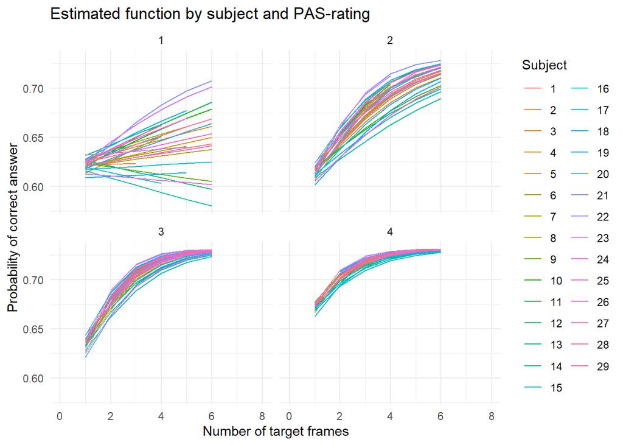

```r
df <- cbind(df, fitted_f = fitted(model_5.2g), probabilities_f = inv.logit(fitted(model_5.2g)))
ggplot(df, aes(x = target.frames, y = probabilities_f, color = subject)) +
  geom_line() +
  xlim(0, 8) +
  labs(x = "Number of target frames",
       y = "Probability of correct answer",
       title = "Estimated function by subject and PAS-rating") +
  scale_color_discrete(name = "Subject") +
  facet_wrap('pas') +
  theme_minimal()
```

```r
summary(model_5.2g)$coefficients
```

```
##                      Estimate Std. Error    z value     Pr(>|z|)
## (Intercept)        -0.1216284 0.06410924 -1.8972049 5.780091e-02
## target.frames       0.1147978 0.03706804  3.0969487 1.955237e-03
## pas2               -0.5713852 0.08936646 -6.3937317 1.618854e-10
## pas3               -0.5385028 0.13935075 -3.8643698 1.113764e-04
## pas4                0.2015944 0.24978165  0.8070824 4.196190e-01
## target.frames:pas2  0.4471811 0.03472564 12.8775465 6.021959e-38
## target.frames:pas3  0.7486935 0.04589213 16.3142051 7.821781e-60
## target.frames:pas4  0.7592723 0.06830478 11.1159468 1.049316e-28
```

```r
inv.logit(-0.12163) #intercept for PAS 1
```

```
## [1] 0.4696299
```

```r
inv.logit(-0.12163 + -0.57139) #slope for PAS 2
```

```
## [1] 0.3333616
```

```r
inv.logit(-0.12163 + -0.53850) #slope for PAS 3
```

```
## [1] 0.3407104
```

```r
inv.logit(-0.12163 + 0.20159) #slope for PAS 4
```

```
## [1] 0.5199794
```

According to the model, when 0 target frames are shown, at PAS-rating 1 accuracy is estimated at 47%, at PAS-rating 2 at 33%, at PAS-rating 3 at 34% and at PAS-rating as 52%. This is not reasonable as it makes no sense to consider perceptual accuracy when no stimulus is perceived, and the model does not take into account that when the participant has two options to choose from and no information, their performance will conceptually be at the level of chance, i.e. at 50% accuracy. While the beta values at PAS-rating 1 and 4 are close to this value, this is due to coincidence rather than use of the aforementioned logic.

## EXERCISE 6 - Test linear hypotheses

In this section we are going to test different hypotheses. We assume that we have already proved that more objective evidence (longer duration of stimuli) is sufficient to increase accuracy in and of itself and that more subjective evidence (higher PAS ratings) is also sufficient to increase accuracy in and of itself.  
We want to test a hypothesis for each of the three neighbouring differences in PAS, i.e. the difference between 2 and 1, the difference between 3 and 2 and the difference between 4 and 3. More specifically, we want to test the hypothesis that accuracy increases faster with objective evidence if subjective evidence is higher at the same time, i.e. we want to test for an interaction.

### 1) Fit a model based on the following formula: `correct ~ pas * target.frames + (target.frames | subject))`

```r
model_6.1a <- glmer(correct ~ pas * target.frames + (target.frames | subject),
                    data = df,
                    family = 'binomial')
```

**i. First, use `summary` (yes, you are allowed to!) to argue that accuracy increases faster with objective evidence for PAS 2 than for PAS 1.**

```r
summary(model_6.1a)
```

```
## Generalized linear mixed model fit by maximum likelihood (Laplace
##   Approximation) [glmerMod]
##  Family: binomial  ( logit )
## Formula: correct ~ pas * target.frames + (target.frames | subject)
##    Data: df
##
##      AIC      BIC   logLik deviance df.resid
##  19506.1  19595.5  -9742.0  19484.1    25033
##
## Scaled residuals:
##      Min       1Q   Median       3Q      Max
## -19.0113   0.0537   0.1606   0.4849   1.4465
##
## Random effects:
##  Groups  Name          Variance Std.Dev. Corr
##  subject (Intercept)   0.03697  0.1923
##          target.frames 0.02057  0.1434   -0.76
## Number of obs: 25044, groups:  subject, 29
##
## Fixed effects:
##                    Estimate Std. Error z value Pr(>|z|)
## (Intercept)        -0.12163    0.06415  -1.896 0.057980 .
## pas2               -0.57139    0.08942  -6.390 1.66e-10 ***
## pas3               -0.53850    0.13955  -3.859 0.000114 ***
## pas4                0.20153    0.25024   0.805 0.420626
## target.frames       0.11480    0.03709   3.095 0.001965 **
## pas2:target.frames  0.44718    0.03474  12.871  < 2e-16 ***
## pas3:target.frames  0.74869    0.04595  16.294  < 2e-16 ***
## pas4:target.frames  0.75929    0.06842  11.098  < 2e-16 ***
## ---
## Signif. codes:  0 '***' 0.001 '**' 0.01 '*' 0.05 '.' 0.1 ' ' 1
##
## Correlation of Fixed Effects:
##             (Intr) pas2   pas3   pas4   trgt.f ps2:t. ps3:t.
## pas2        -0.462
## pas3        -0.308  0.248
## pas4        -0.174  0.121  0.090
## target.frms -0.811  0.306  0.208  0.123
## ps2:trgt.fr  0.482 -0.874 -0.245 -0.124 -0.428
## ps3:trgt.fr  0.393 -0.279 -0.891 -0.111 -0.358  0.370
## ps4:trgt.fr  0.276 -0.163 -0.120 -0.918 -0.260  0.225  0.199
```

```r
# WHEN WORKING WITH INTERACTIONS, YOU ALWAYS ADD EVERY CATEGORY OF FIXED EFFECT THAT THE COMPONENTS APPEAR IN
# For PAS 1 and 1 target frame:
#intercept
#inv.logit(-0.12163)

# For PAS 2 and 1 target frame:
# intercept + effect of PAS 2 + effect of PAS 2 : target frames interaction (since "PAS 2" is present in both and is therefore involved in the outcome)
#inv.logit(-0.12163 + -0.57139 + 0.44718)

# For PAS 1 and 3 target frames:
# intercept + 3 effects of target frames
#inv.logit(-0.12163 + 3 * 0.11480)

# For PAS 2 and 3 target frames:
# intercept + effect of PAS 2 + 3 effects of target frames + effect of PAS 2 : target frames interaction
#inv.logit(-0.12163 + -0.57139 + 3 * 0.11480 + 0.44718)

# Just the interaction effect of PAS 2 * target frames
inv.logit(0.44718)
```

```
## [1] 0.6099685
```

## 2) `summary` won’t allow you to test whether accuracy increases faster with objective evidence for PAS 3 than for PAS 2 (unless you use `relevel`, which you are not allowed to in this exercise). Instead, we’ll be using the function `glht` from the `multcomp` package

**i. To redo the test in 6.1.i, you can create a *contrast* vector. This vector will have the length of the number of estimated group-level effects and any specific contrast you can think of can be specified using this. For redoing the test from 6.1.i, the code snippet below will do.**

```r
# Group-level effects refers to the fixed effects, of which we have 8: (intercept), pas2, pas3, pas4, target.frms, ps2:trgt.fr, ps3:trgt.fr, ps3:trgt.fr
# The elements of the established vector correspond to elements on the list of fixed effects.

# Difference between intercepts of PAS 1 and the interaction 'PAS 2 : target frames' - we have the same intercept, and '1' refers to the fixed effect we are comparing
con_test_1 <- matrix(c(0, 0, 0, 0, 0, 1, 0, 0), nrow = 1)
gh_test_1 <- glht(model_6.1a, con_test_1)
print(summary(gh_test_1))
```

```
##
##   Simultaneous Tests for General Linear Hypotheses
##
## Fit: glmer(formula = correct ~ pas * target.frames + (target.frames |
##     subject), data = df, family = "binomial")
##
## Linear Hypotheses:
##        Estimate Std. Error z value Pr(>|z|)
## 1 == 0  0.44718    0.03474   12.87   <2e-16 ***
## ---
## Signif. codes:  0 '***' 0.001 '**' 0.01 '*' 0.05 '.' 0.1 ' ' 1
## (Adjusted p values reported -- single-step method)
```

```r
# Difference between intercepts of PAS 2 and PAS 3 - '-1' refers to the new baseline, and '1' refers to the fixed effect we are comparing
con_test_2 <- matrix(c(0, -1, 1, 0, 0, 0, 0, 0), nrow = 1)
gh_test_2 <- glht(model_6.1a, con_test_2)
print(summary(gh_test_2))
```

```
##
##   Simultaneous Tests for General Linear Hypotheses
##
## Fit: glmer(formula = correct ~ pas * target.frames + (target.frames |
##     subject), data = df, family = "binomial")
##
## Linear Hypotheses:
##        Estimate Std. Error z value Pr(>|z|)
## 1 == 0  0.03289    0.14588   0.225    0.822
## (Adjusted p values reported -- single-step method)
```

**ii. Now test the hypothesis that accuracy increases faster with objective evidence for PAS 3 than for PAS 2.**

```r
# Difference between interactions 'PAS 2 : target frames' and 'PAS 3 : target frames'
con_2and3 <- matrix(c(0, 0, 0, 0, 0, -1, 1, 0), nrow = 1)
gh_2and3 <- glht(model_6.1a, con_2and3)
summary(gh_2and3)
```

```
##
##   Simultaneous Tests for General Linear Hypotheses
##
## Fit: glmer(formula = correct ~ pas * target.frames + (target.frames |
##     subject), data = df, family = "binomial")
##
## Linear Hypotheses:
##        Estimate Std. Error z value Pr(>|z|)
## 1 == 0  0.30151    0.04622   6.524 6.85e-11 ***
## ---
## Signif. codes:  0 '***' 0.001 '**' 0.01 '*' 0.05 '.' 0.1 ' ' 1
## (Adjusted p values reported -- single-step method)
```

**iii. Also test the hypothesis that accuracy increases faster with objective evidence for PAS 4 than for PAS 3**

```r
# Difference between interactions 'PAS 3 : target frames' and 'PAS 4 : target frames'
con_3and4 <- matrix(c(0, 0, 0, 0, 0, 0, -1, 1), nrow = 1)
gh_3and4 <- glht(model_6.1a, con_3and4)
summary(gh_3and4)
```

```
##
##   Simultaneous Tests for General Linear Hypotheses
##
## Fit: glmer(formula = correct ~ pas * target.frames + (target.frames |
##     subject), data = df, family = "binomial")
##
## Linear Hypotheses:
##        Estimate Std. Error z value Pr(>|z|)
## 1 == 0  0.01060    0.07442   0.142    0.887
## (Adjusted p values reported -- single-step method)
```

### 3) Finally, test that whether the difference between PAS 2 and 1 (tested in 6.1.i) is greater than the difference between PAS 4 and 3 (tested in 6.2.iii)

```r
summary(gh_test_1)
```

```
##
##   Simultaneous Tests for General Linear Hypotheses
##
## Fit: glmer(formula = correct ~ pas * target.frames + (target.frames |
##     subject), data = df, family = "binomial")
##
## Linear Hypotheses:
##        Estimate Std. Error z value Pr(>|z|)
## 1 == 0  0.44718    0.03474   12.87   <2e-16 ***
## ---
## Signif. codes:  0 '***' 0.001 '**' 0.01 '*' 0.05 '.' 0.1 ' ' 1
## (Adjusted p values reported -- single-step method)
```

```r
summary(gh_3and4)
```

```
##
##   Simultaneous Tests for General Linear Hypotheses
##
## Fit: glmer(formula = correct ~ pas * target.frames + (target.frames |
##     subject), data = df, family = "binomial")
##
## Linear Hypotheses:
##        Estimate Std. Error z value Pr(>|z|)
## 1 == 0  0.01060    0.07442   0.142    0.887
## (Adjusted p values reported -- single-step method)
```

Based on the estimates, it seems that the difference between PAS 1 and 2 is greater than the difference between PAS 3 and 4.

## EXERCISE 7 - Estimate psychometric functions for the Perceptual Awareness Scale and evaluate them

We saw in 5.3 that the estimated functions went below chance at a target duration of 0 frames (0 ms). This does not seem reasonable, so we will be trying a different approach for fitting here.  
We will fit the following function that results in a sigmoid, $f(x) = a + \frac {b - a} {1 + e^{\frac {c-x} {d}}}$

It has four parameters: *a*, which can be interpreted as the minimum accuracy level, *b*, which can be interpreted as the maximum accuracy level, *c*, which can be interpreted as the so-called inflexion point, i.e. where the derivative of the sigmoid reaches its maximum and *d*, which can be interpreted as the steepness at the inflexion point. (When *d* goes towards infinity, the slope goes towards a straight line, and when it goes towards 0, the slope goes towards a step function).

We can define a function of a residual sum of squares as below

```r
RSS <- function(dataset, par){
    # "dataset" should be a data.frame containing the variables x (target.frames), y (correct)
    x <- dataset$x
    y <- as.numeric(dataset$y) - 1

    # "par" are our four parameters (a numeric vector): par[1]=a, par[2]=b, par[3]=c, par[4]=d
    a <- par[1]
    b <- par[2]
    c <- par[3]
    d <- par[4]

    #y_hat can be estimated by the sigmoid function
    y_hat <- a + (b - a) / (1 + exp((c - x) / d))

    #and now we calculate the residual sum of squares!
    RSS <- sum((y - y_hat) ^ 2)
    return(RSS)
}
```

### 1) Now, we will fit the sigmoid for the four PAS ratings for Subject 7. However, in order to not take the subject in isolation (and to avoid fitting for too few datapoints) we optimize the function for each PAS rating for all subjects.

```r
# clean up df to run function
df$x <- df$target.frames
df$y <- df$correct

df_1 <- df %>%
  filter(pas == 1)
df_2 <- df %>%
  filter(pas == 2)
df_3 <- df %>%
  filter(pas == 3)
df_4 <- df %>%
  filter(pas == 4)
```

**i. use the function `optim`. It returns a list that among other things contains the four estimated parameters. You should set the following arguments:**

- `par`: you can set *c* and *d* as 1. Find good choices for *a* and *b* yourself (and argue why they are appropriate)
- `fn`: which function to minimise?
- `data`: the data frame with *x*, *target.frames*, and *y*, *correct* in it
- `method`: ‘L-BFGS-B’
- `lower`: lower bounds for the four parameters, (the lowest value they can take), you can set *c* and *d* as `-Inf`. Find good choices for *a* and *b* yourself (and argue why they are appropriate)
- `upper`: upper bounds for the four parameters, (the highest value they can take) can set *c* and *d* as `Inf`.

Find good choices for *a* and *b* yourself (and argue why they are appropriate)

```r
optim_1 <- optim(par = c(0.5, 1, 1, 1),
      fn = RSS,
      data = df_1,
      method = 'L-BFGS-B',
      lower = c(0.5, 0.5, -Inf, -Inf),
      upper = c(1, 1, Inf, Inf))
optim_2 <- optim(par = c(0.5, 1, 1, 1),
      fn = RSS,
      data = df_2,
      method = 'L-BFGS-B',
      lower = c(0.5, 0.5, -Inf, -Inf),
      upper = c(1, 1, Inf, Inf))
optim_3 <- optim(par = c(0.5, 1, 1, 1),
      fn = RSS,
      data = df_3,
      method = 'L-BFGS-B',
      lower = c(0.5, 0.5, -Inf, -Inf),
      upper = c(1, 1, Inf, Inf))
optim_4 <- optim(par = c(0.5, 1, 1, 1),
      fn = RSS,
      data = df_4,
      method = 'L-BFGS-B',
      lower = c(0.5, 0.5, -Inf, -Inf),
      upper = c(1, 1, Inf, Inf))

optim_1
```

```
## $par
## [1] 0.5523047 0.5073848 0.5804910 0.5049069
##
## $value
## [1] 1730.396
##
## $counts
## function gradient
##       32       32
##
## $convergence
## [1] 0
##
## $message
## [1] "CONVERGENCE: REL_REDUCTION_OF_F <= FACTR*EPSMCH"
```

```r
optim_2
```

```
## $par
## [1] 0.5000000 0.8946080 2.9269596 0.5323377
##
## $value
## [1] 973.6214
##
## $counts
## function gradient
##       26       26
##
## $convergence
## [1] 0
##
## $message
## [1] "CONVERGENCE: REL_REDUCTION_OF_F <= FACTR*EPSMCH"
```

```r
optim_3
```

```
## $par
## [1] 0.5000000 0.9693797 2.2207743 0.4327026
##
## $value
## [1] 392.54
##
## $counts
## function gradient
##       23       23
##
## $convergence
## [1] 0
##
## $message
## [1] "CONVERGENCE: REL_REDUCTION_OF_F <= FACTR*EPSMCH"
```

```r
optim_4
```

```
## $par
## [1] 0.5962698 0.9879569 2.0657441 0.4534720
##
## $value
## [1] 150.8497
##
## $counts
## function gradient
##       37       37
##
## $convergence
## [1] 0
##
## $message
## [1] "CONVERGENCE: REL_REDUCTION_OF_F <= FACTR*EPSMCH"
```

For the parameter ‘a’, we chose 0.5 because 50% is the level of chance and it does not make sense to have performance be lower than chance. For parameter ‘b’, we chose 1 because it is impossible to have more than 100% performance. This is also why we set the ‘lower’ values for both parameters ‘a’ and ‘b’ at 0.5 and the ‘upper’ values at 1 - the range of possible values for these parameters is always going to move between chance accuracy (50%) and maximum possible accuracy (100%).

**ii. Plot the fits for the PAS ratings on a single plot (for subject 7) `xlim=c(0, 8)`**

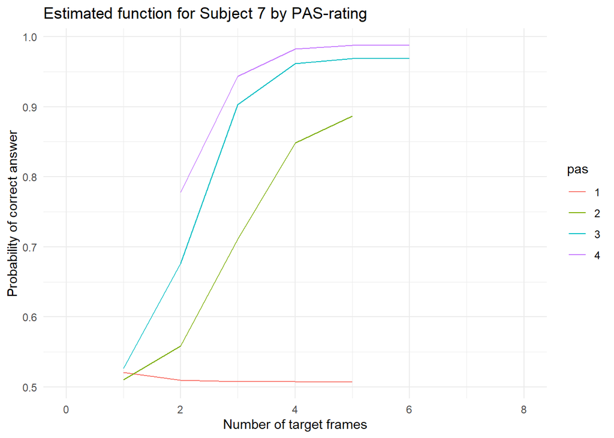

```r
#modify function to output y_hat:
sigmoid_y_hat <- function(dataset, par){
    # "dataset" should be a data.frame containing the variable x (target.frames)
    x <- dataset$x

    # "par" are our four parameters (a numeric vector): par[1]=a, par[2]=b, par[3]=c, par[4]=d
    a <- par[1]
    b <- par[2]
    c <- par[3]
    d <- par[4]

    #y_hat can be estimated by the sigmoid function
    y_hat <- a + (b - a) / (1 + exp((c - x) / d))
    return(y_hat)
}

#get y_hat values (by plugging in the optimized parameters)
y_hat <- sigmoid_y_hat(df_1, optim_1$par)
df_1 <- cbind(df_1, y_hat)

y_hat <- sigmoid_y_hat(df_2, optim_2$par)
df_2 <- cbind(df_2, y_hat)

y_hat <- sigmoid_y_hat(df_3, optim_3$par)
df_3 <- cbind(df_3, y_hat)

y_hat <- sigmoid_y_hat(df_4, optim_4$par)
df_4 <- cbind(df_4, y_hat)

# FILTER FOR SUBJECT 7
df_1_7 <- df_1 %>%
  filter(subject == 7)
df_2_7 <- df_2 %>%
  filter(subject == 7)
df_3_7 <- df_3 %>%
  filter(subject == 7)
df_4_7 <- df_4 %>%
  filter(subject == 7)

df_7 <- rbind(df_1_7, df_2_7, df_3_7, df_4_7)

# PLOT
# PAS 1
ggplot(df_7, aes(x = target.frames, y = y_hat, color = pas)) +
  geom_line() +
  xlim(0, 8) +
  labs(x = "Number of target frames",
       y = "Probability of correct answer",
       title = "Estimated function for Subject 7 by PAS-rating") +
  theme_minimal()
```

**iii. Create a similar plot for the PAS ratings on a single plot (for subject 7), but this time based on the model from 6.1 `xlim=c(0, 8)`**

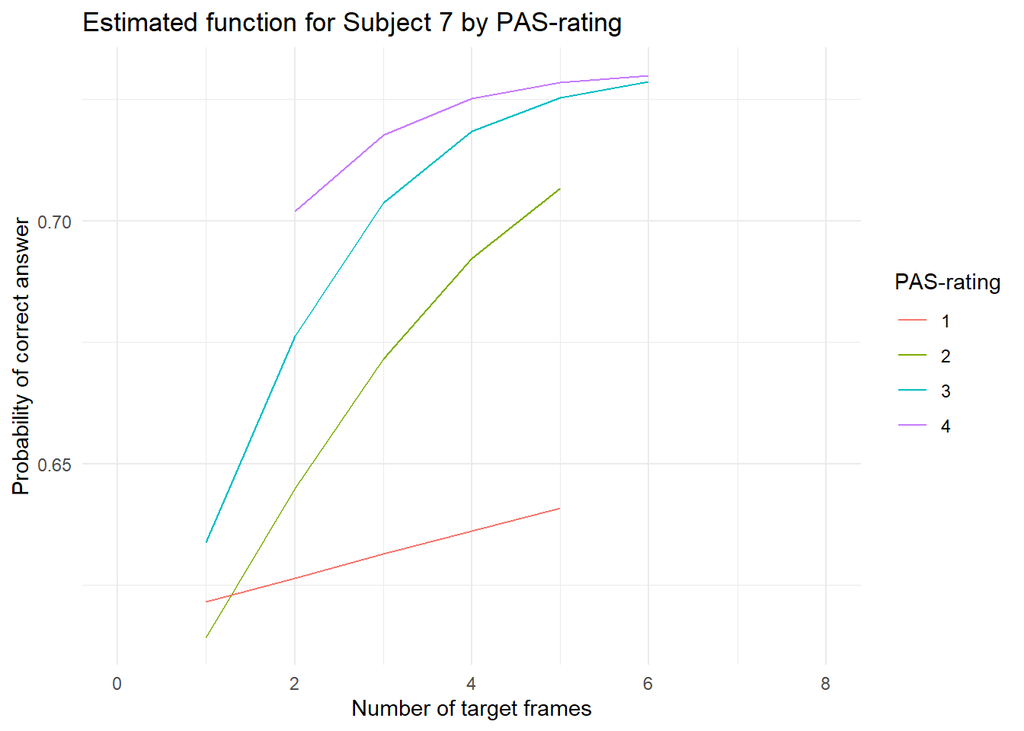

```r
df <- cbind(df, fitted6.1 = inv.logit(fitted(model_6.1a)))
df7 <- df %>% filter(subject == 7)
ggplot(df7, aes(x = target.frames, y = fitted6.1, color = pas)) +
  geom_line() +
  xlim(0, 8) +
  labs(x = "Number of target frames",
       y = "Probability of correct answer",
       title = "Estimated function for Subject 7 by PAS-rating") +
  scale_color_discrete(name = "PAS-rating") +
  theme_minimal()
```

**iv. Comment on the differences between the fits - mention some advantages and disadvantages of each way**

In broad lines, the two estimation procedures yield similar results. An advantage of using a sigmoid function with optimized parameters is that the estimated function does not yield illogical estimates (such as performance that is worse than chance when the participant perceives no stimulus due to none being shown); however, parameter optimization relies on subsetting the data, meaning that the entire dataset is never taken into consideration as a whole, meaning that e.g. at PAS rating 1, subject 7’s performance appears to decline the more target frames they are shown.

### 2) Finally, estimate the parameters for all subjects and each of their four PAS ratings. Then plot the estimated function at the group-level by taking the mean for each of the four parameters, *a*, *b*, *c* and *d* across subjects. A function should be estimated for each PAS-rating (it should look somewhat similar to Fig. 3 from the article: https://doi.org/10.1016/j.concog.2019.03.007)

Estimate parameters for each subject and PAS-rating:

```r
data = as.data.frame(c()) # empty data frame to receive values

for (i in 1:29) {
  by_subject <- df %>%
    filter(subject == i) # take each subject

  for(j in 1:4){
    by_pas <- by_subject %>%
      filter(pas == j) # take each pas

    optimized <- optim(par = c(0.5, 1, 1, 1),
                      fn = RSS,
                      data = by_pas,
                      method = c("L-BFGS-B"),
                      lower = c(0.5, 0.5, -Inf, -Inf),
                      upper = c(1 ,1, Inf, Inf)
                      ) # optimize the parameters

    temp <- data.frame(a = optimized$par[1],
                       b = optimized$par[2],
                       c = optimized$par[3],
                       d = optimized$par[4],
                       subject = i,
                       pas = j) # put all info into data frame

    data <- rbind(data, temp) # append to existing data
  }
}
```

Take the mean for each PAS-rating:

```r
means <- data %>%
  group_by(pas) %>%
  summarize("a_mean" = mean(a),
            "b_mean" = mean(b),
            "c_mean" = mean(c),
            "d_mean" = mean(d)) # find the means

par_pas_1 = c(means$a_mean[1],
              means$b_mean[1],
              means$c_mean[1],
              means$d_mean[1])

par_pas_2 = c(means$a_mean[2],
              means$b_mean[2],
              means$c_mean[2],
              means$d_mean[2])

par_pas_3 = c(means$a_mean[3],
              means$b_mean[3],
              means$c_mean[3],
              means$d_mean[3])

par_pas_4 = c(means$a_mean[4],
              means$b_mean[4],
              means$c_mean[4],
              means$d_mean[4]) # extract the means into the appropriate vector
```

Calculate *y_hat* using the RSS-function that I modified to output *y_hat* instead of *RSS*:

```r
y_hat_all <- sigmoid_y_hat(df_1, par_pas_1)
df_1 <- cbind(df_1, y_hat_all)

y_hat_all <- sigmoid_y_hat(df_2, par_pas_2)
df_2 <- cbind(df_2, y_hat_all)

y_hat_all <- sigmoid_y_hat(df_3, par_pas_3)
df_3 <- cbind(df_3, y_hat_all)

y_hat_all <- sigmoid_y_hat(df_4, par_pas_4)
df_4 <- cbind(df_4, y_hat_all)

plotting_df = rbind(df_1, df_2, df_3, df_4)
```

Plot:

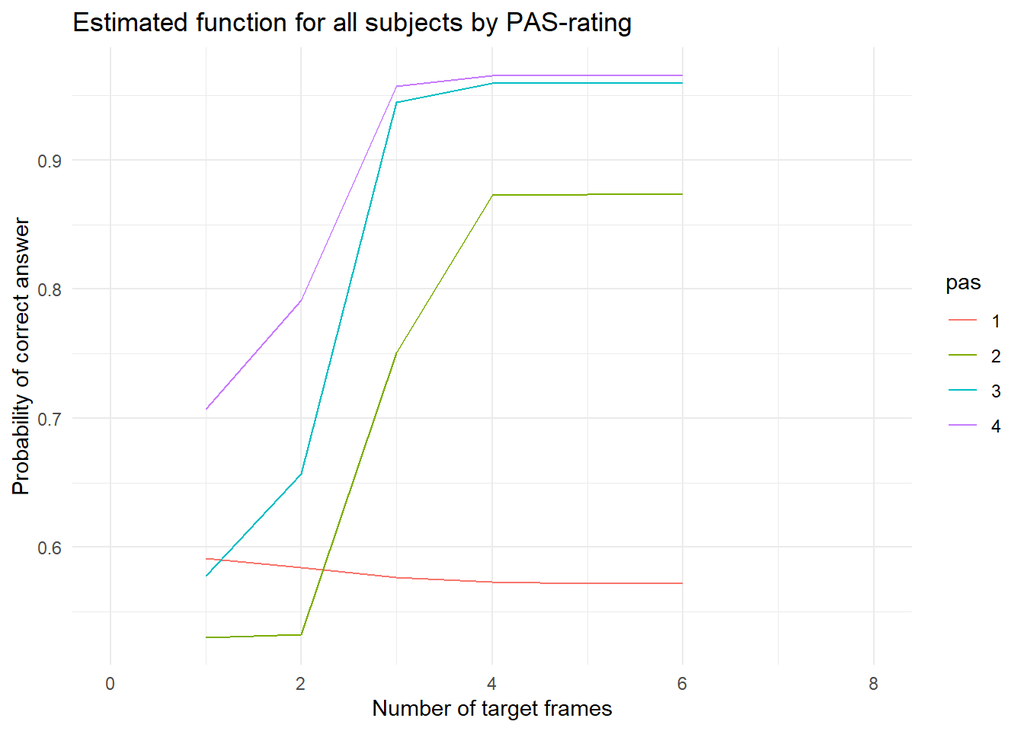

```r
ggplot(plotting_df, aes(x = target.frames, y = y_hat_all, color = pas)) +
  geom_line() +
  xlim(0, 8) +
  labs(x = "Number of target frames",
       y = "Probability of correct answer",
       title = "Estimated function for all subjects by PAS-rating") +
  theme_minimal()
```

**i. compare with the figure you made in 5.3.ii and comment on the differences between the fits - mention some advantages and disadvantages of both.**

Both plots illustrate similar tendencies in the data. The model using the sigmoid function has the advantage of not outputting unreasonable results such as accuracy levels lower than chance. However, what cannot be seen on an aggregated plot of means, and that is clearly seen in the plot for 5.3.ii, is that there does not appear to be any systemacity to accuracy ratings for participants at PAS 1; the sigmoid plot actually outputs that as the number of target frames increases, accuracy decreases, which is unreasonable.